# TP CMI 2021 - exploitation de sortie 25 février 2021

C. Plumejeaud-Perreau

03/03/2021

## Configure your environment

```r
#setwd("~/R/TP_CMI")
setwd("C:/Travail/CNRS_mycore/PAMELI/Scripts/")
getwd()
```

```
## [1] "C:/Travail/CNRS_mycore/PAMELI/Scripts"
```

```r
# Ajouter meslibrairiesR dans ces chemins :
meslibrairiesR <- "C:/Tools/R4"
.libPaths(c( .libPaths(), meslibrairiesR) )

#install.packages("tidyverse")
## Charger les libraries
library(tidyverse)
library(lubridate)

#Pour les correlations
library(corrplot)
library(texreg)
library(Hmisc)

## Carto
library(sf)
library(cartography)
library(sp) #pour bbox
library(tmap)

## Markdown
library(knitr)
library(rmarkdown)
library(markdown)
```

## Lire les données

```r
data <- read.csv("aytre_25fev2021_ysiexo2_gps.csv", header=TRUE, sep=";", dec=",", stringsAsFactors=FALSE, encoding = "UTF-8")
```

Notez que les types des variables ne sont pas reconnus

```r
summary(data)
```

```
##    context_id    reason              date           sensor_name
##  Min.   :1    Length:51768       Length:51768       Length:51768
##  1st Qu.:1    Class :character   Class :character   Class :character
##  Median :1    Mode  :character   Mode  :character   Mode  :character
##  Mean   :1
##  3rd Qu.:1
##  Max.   :1
##  property_name      property_value    unit_code          unit_name
##  Length:51768       Min.   :  0.00   Length:51768       Length:51768
##  Class :character   1st Qu.:  6.18   Class :character   Class :character
##  Mode  :character   Median : 11.35   Mode  :character   Mode  :character
##                     Mean   : 21.93
##                     3rd Qu.: 26.95
##                     Max.   :181.13
##    point_id          pt_longitude     pt_latitude     geom_point
##  Length:51768       Min.   :-1.142   Min.   :46.12   Length:51768
##  Class :character   1st Qu.:-1.136   1st Qu.:46.12   Class :character
##  Mode  :character   Median :-1.132   Median :46.12   Mode  :character
##                     Mean   :-1.133   Mean   :46.12
##                     3rd Qu.:-1.129   3rd Qu.:46.12
##                     Max.   :-1.128   Max.   :46.13
##   local_time        is_reference
##  Length:51768       Length:51768
##  Class :character   Class :character
##  Mode  :character   Mode  :character
##
##
##
```

point_id devrait être un entier, mais il est lu comme une chaîne de caractères “75 177” au lieu de 75177

```r
res <- vector("integer", length(data$point_id))
for (k in 1:length(data$point_id)){
  res[k] <- as.integer(gsub("[^0-9]", "", data$point_id[k]))
}
data$point_id <-res
```

Utiliser mutate de tidyverse pour convertir les variables dans leur bon type

```r
data <- data %>%
  mutate_at(vars(sensor_name, property_name, unit_code, unit_name), list(as.factor))  %>%
  mutate_at(vars(property_value, pt_longitude, pt_latitude), list(as.numeric)) %>%
  mutate_at(vars(is_reference), list(as.logical))
```

Process time and spatial dimension

```r
data <- data %>%
  mutate(date = ymd(data$date)) %>%
  mutate(local_time = as_datetime(data$local_time))%>%
  mutate(geom_point = st_as_sfc(data$geom_point))
```

Convert data to a spatial dataframe R uses Simple Features (sf) , read https://r-spatial.github.io/sf/articles/sf1.html

```r
datasf <- st_as_sf(data)
datasf <- st_set_crs(datasf, 4326)
```

Vérifier

```r
data[1,]$local_time #"2021-02-25 13:58:01 UTC"
```

```
## [1] "2021-02-25 13:58:01 UTC"
```

```r
data[1,]$date #"2021-02-25" ymd
```

```
## [1] "2021-02-25"
```

```r
summary(datasf)
```

```
##    context_id    reason               date             sensor_name
##  Min.   :1    Length:51768       Min.   :2021-02-25   ysiexo2:51768
##  1st Qu.:1    Class :character   1st Qu.:2021-02-25
##  Median :1    Mode  :character   Median :2021-02-25
##  Mean   :1                       Mean   :2021-02-25
##  3rd Qu.:1                       3rd Qu.:2021-02-25
##  Max.   :1                       Max.   :2021-02-25
##
##             property_name   property_value     unit_code
##  chlorophyll_mg/L  : 5752   Min.   :  0.00   %Sat   : 5752
##  conductivity_mS/cm: 5752   1st Qu.:  6.18   C      : 5752
##  depth_m           : 5752   Median : 11.35   m      : 5752
##  fDOM_rfu          : 5752   Mean   : 21.93   mS/cm  : 5752
##  ODOsat_%sat       : 5752   3rd Qu.: 26.95   NTU    : 5752
##  pH                : 5752   Max.   :181.13   pH     : 5752
##  (Other)           :17256                    (Other):17256
##                       unit_name        point_id       pt_longitude
##  Celsius_degrees           : 5752   Min.   :    19   Min.   :-1.142
##  meters                    : 5752   1st Qu.:227159   1st Qu.:-1.136
##  microgramms/liter         : 5752   Median :446386   Median :-1.132
##  milliSiemens/centimeter   : 5752   Mean   :428663   Mean   :-1.133
##  NephelometricTurbidityUnit: 5752   3rd Qu.:646440   3rd Qu.:-1.129
##  parts_per_thousand        : 5752   Max.   :783985   Max.   :-1.128
##  (Other)                   :17256
##   pt_latitude      local_time                  is_reference
##  Min.   :46.12   Min.   :2021-02-25 13:53:45   Mode :logical
##  1st Qu.:46.12   1st Qu.:2021-02-25 14:17:53   FALSE:51768
##  Median :46.12   Median :2021-02-25 14:42:00
##  Mean   :46.12   Mean   :2021-02-25 14:41:59
##  3rd Qu.:46.12   3rd Qu.:2021-02-25 15:06:05
##  Max.   :46.13   Max.   :2021-02-25 15:30:13
##
##          geom_point
##  POINT        :51768
##  epsg:4326    :    0
##  +proj=long...:    0
##
##
##
##
```

## Une carte toute simple avec cartography

Emprise de la sortie, trait de cote, et trajectoire du drone

### 1. Lecture du fond de carte

```r
getwd() #Vérifier votre répertoire de travail
```

```
## [1] "C:/Travail/CNRS_mycore/PAMELI/Scripts"
```

```r
library("sf")
library("cartography")
```

- Cadre

```r
footprint<-st_read(dsn="shp/emprise_Aytre_17092020_4326.shp", stringsAsFactors = FALSE)
```

- Cote

```r
cote<-st_read(dsn="shp/cote_GSHHS_f_L1_4326.shp", stringsAsFactors = FALSE)
cote_precise<-st_read(dsn="shp/cote_precise_line_4326.shp", stringsAsFactors = FALSE)
```

- Trajectoire du drone (simplifiée)

```r
drone_path<-st_read(dsn="shp/curve_Aytre_25022021_4326.shp", stringsAsFactors = FALSE)
```

- 20 points d’échantillonage théorique

```r
sampling<-st_read(dsn="geojson/sampling_4326.geojson", stringsAsFactors = FALSE)
colnames(sampling)
```

```
##  [1] "id"                "nom"               "coord_x"
##  [4] "coord_y"           "Heure.1"           "Heure.2"
##  [7] "Poche"             "vol"               "purge"
## [10] "commentair"        "Date..MM.D"        "Time..HH_m"
## [13] "Time..Frac"        "Sec."              "Site.Name"
## [16] "Chlorophyl"        "Chloroph_1"        "Cond..U.FFFD.S."
## [19] "fDOM.QSU"          "fDOM.RFU"          "nLF.Cond..U.FFFD."
## [22] "ODO...sat"         "ODO...loca"        "ODO.mg.L"
## [25] "ORP.mV"            "Sal.psu"           "SpCond..U.FFFD."
## [28] "BGA.PE.RFU"        "BGA.PE.ug."        "TDS.mg.L"
## [31] "Turbidity"         "TSS.mg.L"          "pH"
## [34] "pH.mV"             "Temp..U.FFFD.C"    "Battery.V"
## [37] "Cable.Pwr"         "field_38"          "field_39"
## [40] "field_40"          "geometry"
```

### 2. Dessin de la carte

Les couches et styles cartographiques s’empilent les uns sur les autres dans l’ordre d’appel comme dans un SIG classique

Refaire le graphique avec des marges réduites. Réduire la largeur des marges avec par(mar=()) : c(bas, gauche, haut, droite)

- OMA : augmenter la largeur de la MARGE EXTERNE (oma) sur les bords gauche et droit de 1
- MAR : reduire la largeur de la MARGE INTERNE (mar), sauf en haut ( + 1.5)

```r
dev.off()
```

```r
par(mar = c(0.5,0,1.5,0), oma = c(0,7,0,7))
```

La carte basique avec les polygones, le cartouche, la légende, l’échelle, etc.

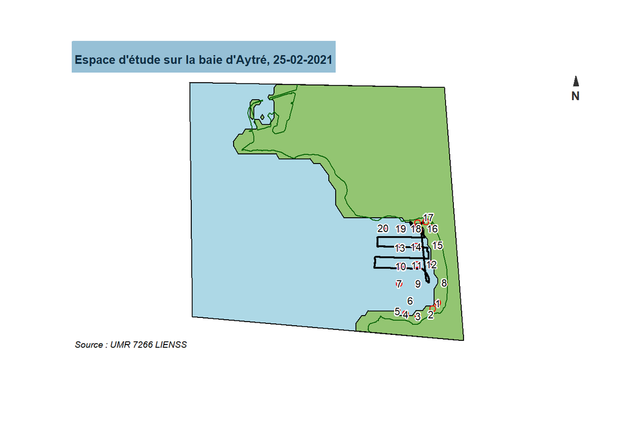

```r
plot(st_geometry(footprint), col="lightblue", lwd=1)
plot(st_geometry(cote), col="#93C572", add=T)
plot(st_geometry(cote_precise), col="#006400", add=T)

plot(st_geometry(drone_path), col="black", add=T, lwd=2)
plot(st_geometry(sampling), col="red", add=T)
labelLayer(x = sampling, txt="id", halo= TRUE,overlap=FALSE)

# Rajouter le cartouche, la légende, l'échelle, etc.
#Options : https://rdrr.io/cran/cartography/man/layoutLayer.html
layoutLayer(title = "Espace d'étude sur la baie d'Aytré, 25-02-2021",
            sources = "Source : UMR 7266 LIENSS",
            scale = FALSE, tabtitle = TRUE,
            frame = FALSE,theme = "blue.pal",
            north = TRUE)
```

### 3. Zoomer sur la zone à échantillonner (Aytré)

Calculer des bornes en coordonnées géographiques (longitude, latitude)

```r
zzoom <- bbox(SpatialPoints(cbind(sampling$coord_x, sampling$coord_y)))
view(zzoom)
```

Prendre 10% de marge en hauteur et 15 % en largeur

```r
deltax <- (zzoom[1,2]-zzoom[1,1])*0.15
deltay <- (zzoom[2,2]-zzoom[2,1])*0.1
```

Calcul des points extrêmes : st_point(x, y) avec x = longitude, y=latitude

```r
sudouest <- st_point(c(zzoom[1,1]-deltax,zzoom[2,1]-deltay))
sudest <- st_point(c(zzoom[1,2]+deltax,zzoom[2,1]-deltay))
nordouest <- st_point(c(zzoom[1,1]-deltax,zzoom[2,2]+deltay))
nordest <- st_point(c(zzoom[1,2]+deltax,zzoom[2,2]+deltay))
```

Fabrique du polygone rectangle d’emprise

```r
p1 <- rbind(sudouest, nordouest, nordest, sudest, sudouest)
pol <-st_polygon(list(p1))
zzoom_sf <- st_sfc(pol, crs=4326)
```

Découpe des autres géometries pour ne retenir que l’intersection avec ce rectangle

```r
footprintz <- st_intersection(x = footprint, y = zzoom_sf)
cotez <- st_intersection(x = cote, y = zzoom_sf)
coteprecisez <- st_intersection(x = cote_precise, y = zzoom_sf)
drone_pathz <- st_intersection(x = drone_path, y = zzoom_sf)
```

Limiter les données à celles de la zone d’Aytré

```r
datasfz <- st_intersection(x = datasf, y = zzoom_sf)
```

```r
par(mar = c(0.5,0,1.5,0), oma = c(0,1,0,1))
```

La carte basique avec les polygones, le cartouche, la légende, l’échelle, etc Options : https://rdrr.io/cran/cartography/man/layoutLayer.html

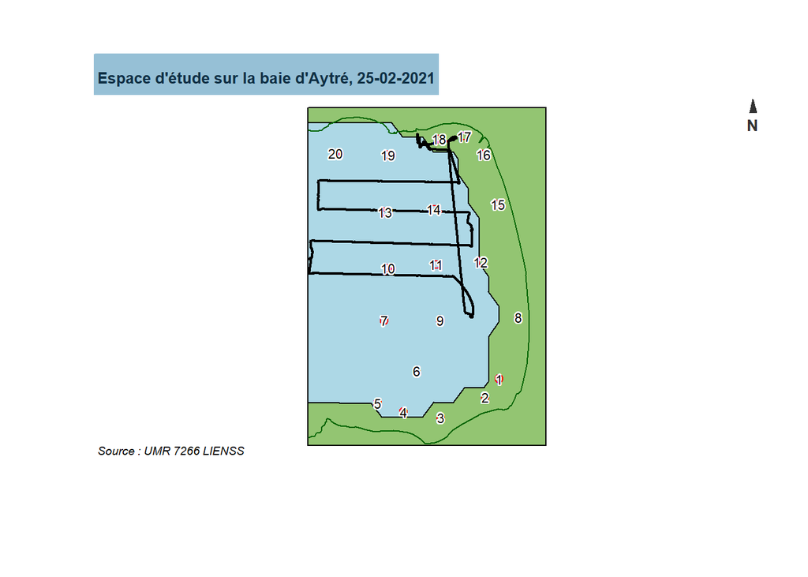

### 4. Créer le template cartographique avec tmap

- [exemple !](https://github.com/riatelab/mexusaborder/blob/master/texmex.R)

```r
library(tmap)
tmap_mode("plot") ##One option


basemap <- function(titlep = "") {
  par(mar = c(1,0,1.5,0), oma = c(2,7,0,7))

  map <- tm_shape(footprintz) +
    tm_borders() +
    tm_shape(coteprecisez) +
    tm_lines(col="#006400", lwd=2) + ##vert foncé
    tm_scale_bar(position = c(0.05,0.2)) +
    tm_compass(position = c(0.05,0.3)) +
    tm_layout(main.title = titlep,
              main.title.size=0.7,
              title.bg.color="#59C7EB",
              legend.outside = TRUE)
  return (map)
}
```

Utiliser le template pour exporter en resolution 150 DPI la carte avec la trace du drone et les points d’échantillonage

```r
sizes_aea <- getFigDim(x = zzoom_sf, mar = c(0,0,1.2,0), res = 150)
png("outputs/fig03.png", width = sizes_aea[1], height = sizes_aea[2], res = 150)
map <- basemap("Zoom sur l'espace d'étude : la baie d'Aytré, \n 25-02-2021")
```

Voir ce template

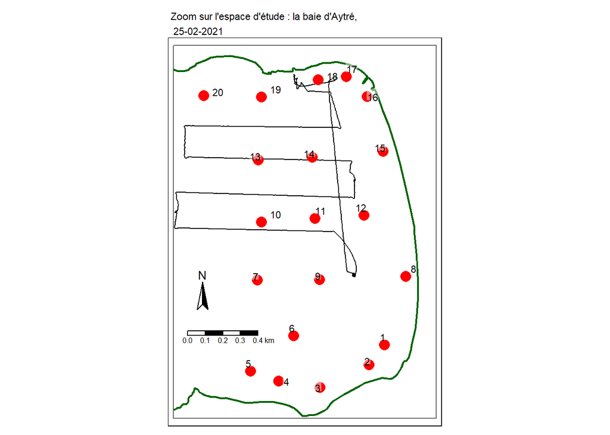

```r
map <- map+
  tm_shape(drone_pathz) +
  tm_lines(col="black") + #Trace du drone
  tm_shape(sampling) +
  tm_dots(col = "red", size=0.7)+ #Points d'échantillonage
  tm_text("id", size=0.7, auto.placement=TRUE, bg.color="white", bg.alpha=0.5, just=c(0,0))

map #Dessiner la carte dans le device (ici le fichier fig03.png)
```

```r
dev.off() ## Fermer et sauver le fichier fig03.png
```

```r
map #Voir la carte dans Plots

dev.off() ## Effacer les plots
```

## Analyser l’évolution des paramètres mesurés

### 1. evolution des paramètres

Le problème est que les unités de valeurs ne sont pas comparables

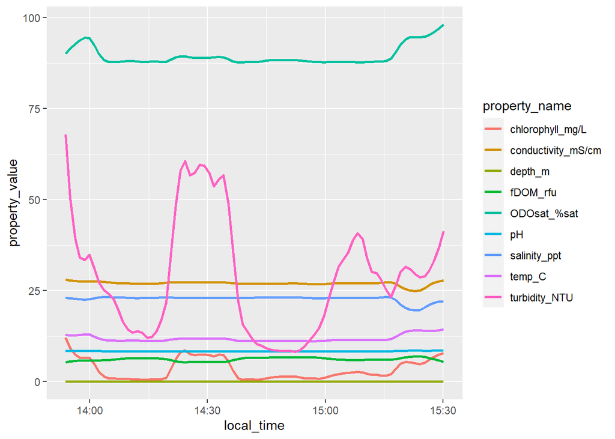

```r
ggplot(data=datasfz, aes(x=local_time, y=property_value, colour=property_name)) +
  geom_smooth(method = 'loess', formula = 'y ~ x', span = 0.1, se=FALSE)
```

Méthode :

- On filtre sur les 4 variables d’intérêt
- Puis on regroupe par ces 4 variables (group_by)
- Puis on calcule un nouvel indicateur ‘ratio’ sans unité, qui vaut 0 quand la variable est moyenne
- Puis on calcule un nouvel indicateur ‘std’ sans unité, qui vaut 0 quand la variable est moyenne mais dont l’écart est standardisé

```r
subsetdatasf <- datasfz %>%
  filter(property_name %in% c('turbidity_NTU', 'temp_C','salinity_ppt','chlorophyll_mg/L' ) ) %>%
  group_by(property_name) %>%
  mutate(ratio = -(1-(property_value/mean(property_value))))%>%
  mutate(std = (property_value-mean(property_value))/(sd(property_value)))
```

Seulement property_name est une variable factorielle, qui a gardé l’ensemble de ses 9 levels, même après le tri sur 4 variables

```r
unique(subsetdatasf$property_name)
```

```
## [1] salinity_ppt     temp_C           turbidity_NTU    chlorophyll_mg/L
## 9 Levels: chlorophyll_mg/L conductivity_mS/cm depth_m fDOM_rfu ... turbidity_NTU
```

On reset donc les levels pour 4 niveaux (notez qu’on nomme “chlorophyll_mg/L” en “chlorophyll_RFU”, c’est un abus…)

```r
levels(subsetdatasf$property_name) <- list(temp_C="temp_C", turbidity_NTU="turbidity_NTU", chlorophyll_RFU="chlorophyll_mg/L", salinity_ppt="salinity_ppt")
```

#### 1.1 Evolution de la turbidité

Filtrer le dataset zoomé sur Aytré pour ne traiter que turbidity Critère : property_name==‘turbidity_NTU’

```r
oneparam <- subsetdatasf %>%
  filter(property_name=='turbidity_NTU')
```

Résumé statistique rapide

```r
summary(oneparam)
```

```
##    context_id    reason               date             sensor_name
##  Min.   :1    Length:5752        Min.   :2021-02-25   ysiexo2:5752
##  1st Qu.:1    Class :character   1st Qu.:2021-02-25
##  Median :1    Mode  :character   Median :2021-02-25
##  Mean   :1                       Mean   :2021-02-25
##  3rd Qu.:1                       3rd Qu.:2021-02-25
##  Max.   :1                       Max.   :2021-02-25
##
##          property_name  property_value     unit_code
##  temp_C         :   0   Min.   :  8.17   NTU    :5752
##  turbidity_NTU  :5752   1st Qu.: 13.49   %Sat   :   0
##  chlorophyll_RFU:   0   Median : 27.09   C      :   0
##  salinity_ppt   :   0   Mean   : 28.43   m      :   0
##                         3rd Qu.: 36.68   mS/cm  :   0
##                         Max.   :181.13   pH     :   0
##                                          (Other):   0
##                       unit_name       point_id       pt_longitude
##  NephelometricTurbidityUnit:5752   Min.   :    19   Min.   :-1.142
##  Celsius_degrees           :   0   1st Qu.:227159   1st Qu.:-1.136
##  meters                    :   0   Median :446386   Median :-1.132
##  microgramms/liter         :   0   Mean   :428663   Mean   :-1.133
##  milliSiemens/centimeter   :   0   3rd Qu.:646440   3rd Qu.:-1.129
##  parts_per_thousand        :   0   Max.   :783985   Max.   :-1.128
##  (Other)                   :   0
##   pt_latitude      local_time                  is_reference
##  Min.   :46.12   Min.   :2021-02-25 13:53:45   Mode :logical
##  1st Qu.:46.12   1st Qu.:2021-02-25 14:17:53   FALSE:5752
##  Median :46.12   Median :2021-02-25 14:42:00
##  Mean   :46.12   Mean   :2021-02-25 14:41:59
##  3rd Qu.:46.12   3rd Qu.:2021-02-25 15:06:05
##  Max.   :46.13   Max.   :2021-02-25 15:30:13
##
##          geom_point       ratio              std
##  POINT        :5752   Min.   :-0.7126   Min.   :-1.22109
##  epsg:4326    :   0   1st Qu.:-0.5256   1st Qu.:-0.90063
##  +proj=long...:   0   Median :-0.0472   Median :-0.08087
##                       Mean   : 0.0000   Mean   : 0.00000
##                       3rd Qu.: 0.2901   3rd Qu.: 0.49707
##                       Max.   : 5.3707   Max.   : 9.20238
##
```

```r
colnames(oneparam)
```

```
##  [1] "context_id"     "reason"         "date"           "sensor_name"
##  [5] "property_name"  "property_value" "unit_code"      "unit_name"
##  [9] "point_id"       "pt_longitude"   "pt_latitude"    "local_time"
## [13] "is_reference"   "geom_point"     "ratio"          "std"
```

```r
summary(oneparam$ratio)
```

```
##    Min. 1st Qu.  Median    Mean 3rd Qu.    Max.
## -0.7126 -0.5256 -0.0472  0.0000  0.2901  5.3707
```

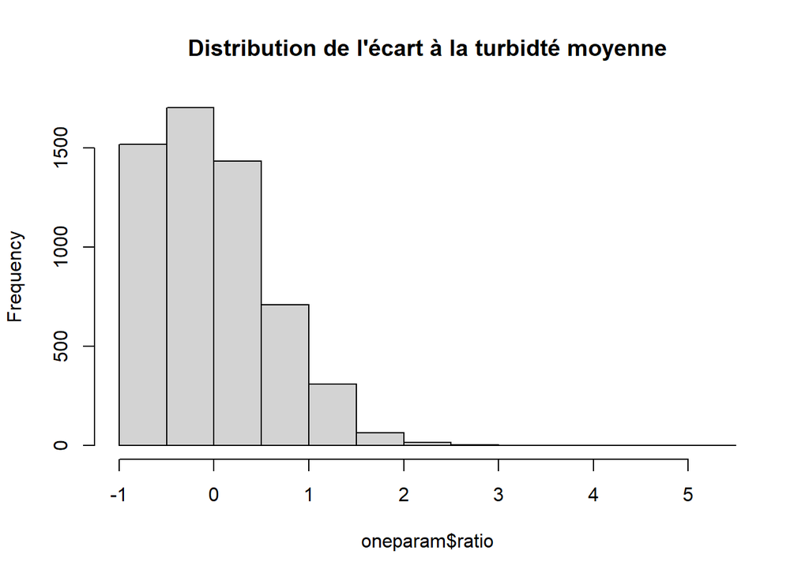

```r
hist(oneparam$ratio, main="Distribution de l'écart à la turbidté moyenne")
```

##### 1.1.1 turbidity dans le temps

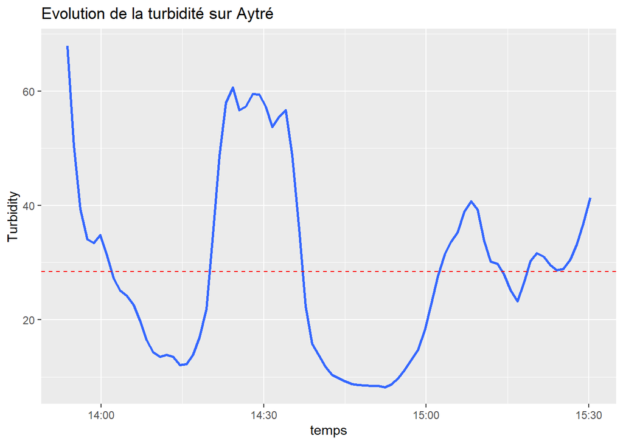

```r
g <- ggplot(oneparam , aes(x=local_time, y=property_value))
g <- g + geom_smooth(method = 'loess', formula = 'y ~ x', span = 0.1, se=FALSE)
g <- g + geom_hline(yintercept=mean(oneparam$property_value), linetype="dashed", color = "red")
g <- g + ggtitle("Evolution de la turbidité sur Aytré") # pour le titre principal
g <- g  + xlab("temps") # pour le titre de l'axe des x
g <- g  + ylab("Turbidity") # pour le titre de l'axe des y

g
```

```r
#dev.copy(png,'./outputs/turbidity_zoom.png')
#dev.off()
```

##### 1.1.2 ratio dans le temps

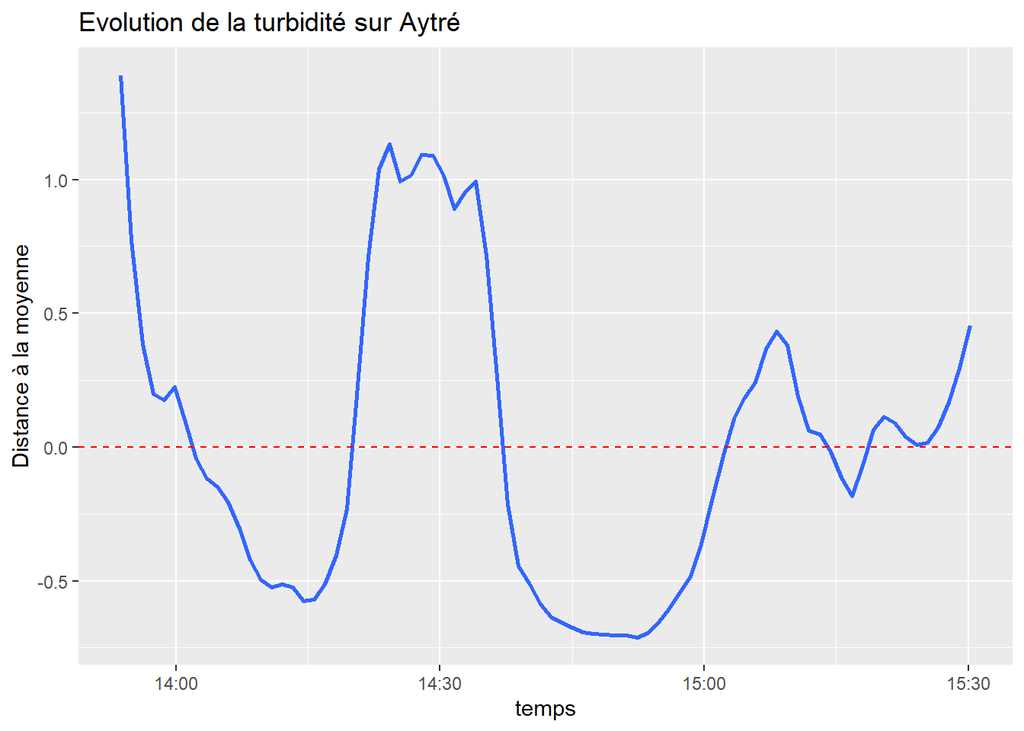

##### 1.1.3 std dans le temps

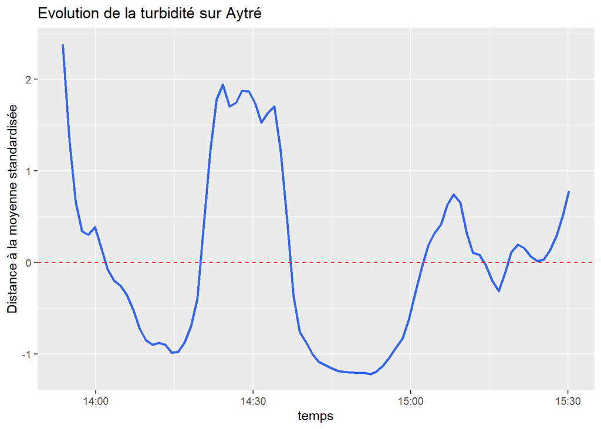

##### 1.1.4 Carto de cette évolution

- [exemple!](https://github.com/riatelab/mexusaborder/blob/master/texmex.R)
- [aide tmap!](https://bookdown.org/nicohahn/making_maps_with_r5/docs/tmap.html)

Appeler le fond de carte et déterminer la taille de la figure pour une résolution de 150 DPI

```r
library(tmap)
dev.off()
```

```r
map <- basemap("Espace d'étude : la baie d'Aytré, 25-02-2021")
tmap_mode("plot") ##One option
#tmap_mode("view") ##Or the other
sizes_aea <- getFigDim(x = zzoom_sf, mar = c(0,0,1.2,0), res = 150)
```

Choisir sa palette de couleur

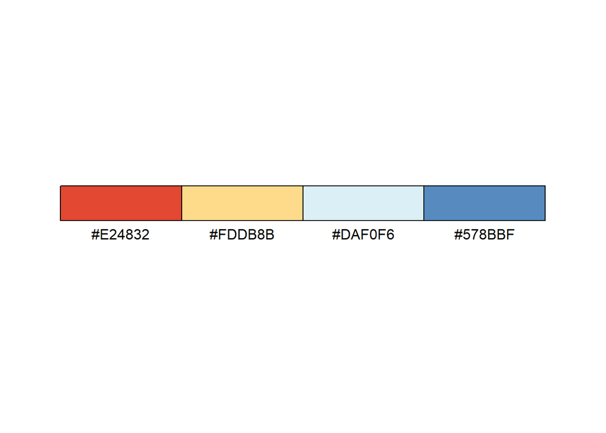

```r
# tmaptools::palette_explorer()
maPalette <- tmaptools::get_brewer_pal("RdYlBu", n = 4)
```

Carte de turbidité

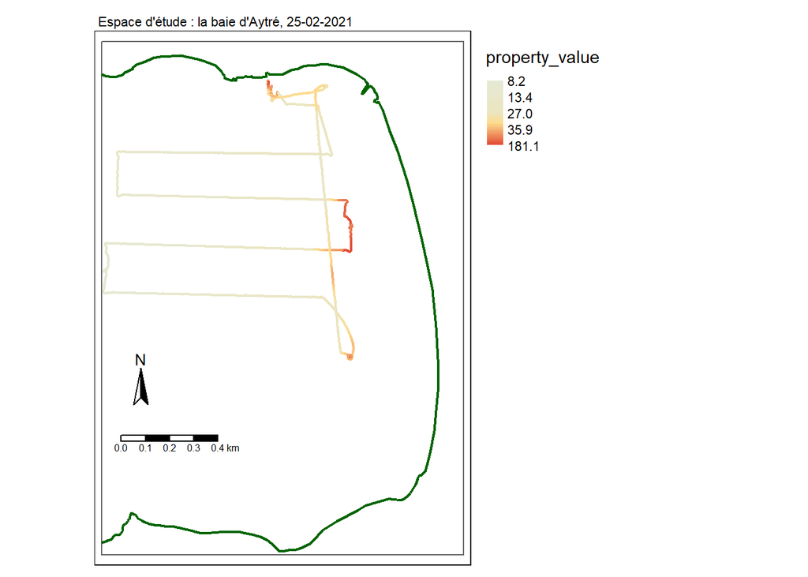

```r
#png("outputs/raw_turbidity_map_zoom.png", width = sizes_aea[1], height = sizes_aea[2], res = 150)
map_param <- map +
  tm_shape(oneparam) +
  tm_dots(col = "property_value",
        midpoint = median(oneparam$property_value),
        palette=rev(maPalette),
        style="order")
map_param
```

```r
#dev.off()
```

Carte de std de turbidité

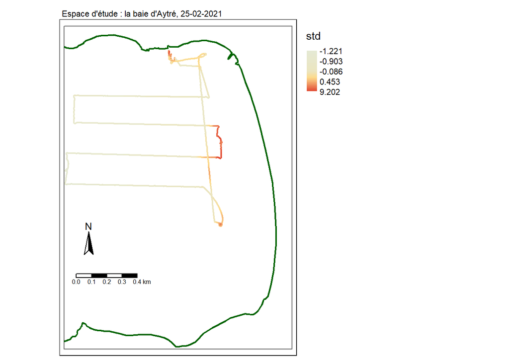

#### 1.2 Refaire pour température, salinity, chlorophylle

Filtrer le dataset zoomé sur Aytré pour ne traiter que température Critère : property_name==‘temp_C’

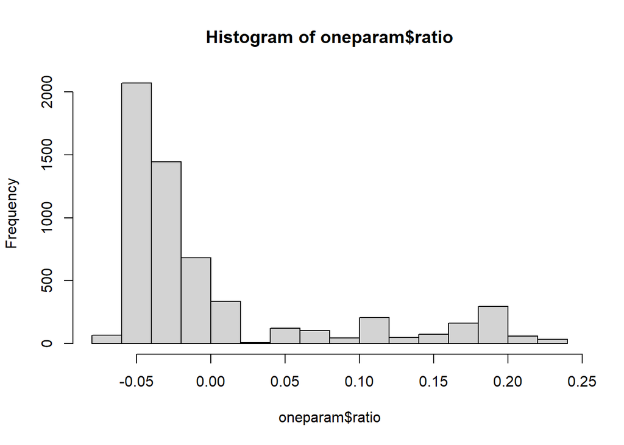

```r
oneparam <- subsetdatasf %>%
  filter(property_name=='temp_C')

hist(oneparam$ratio)
```

Carte de température

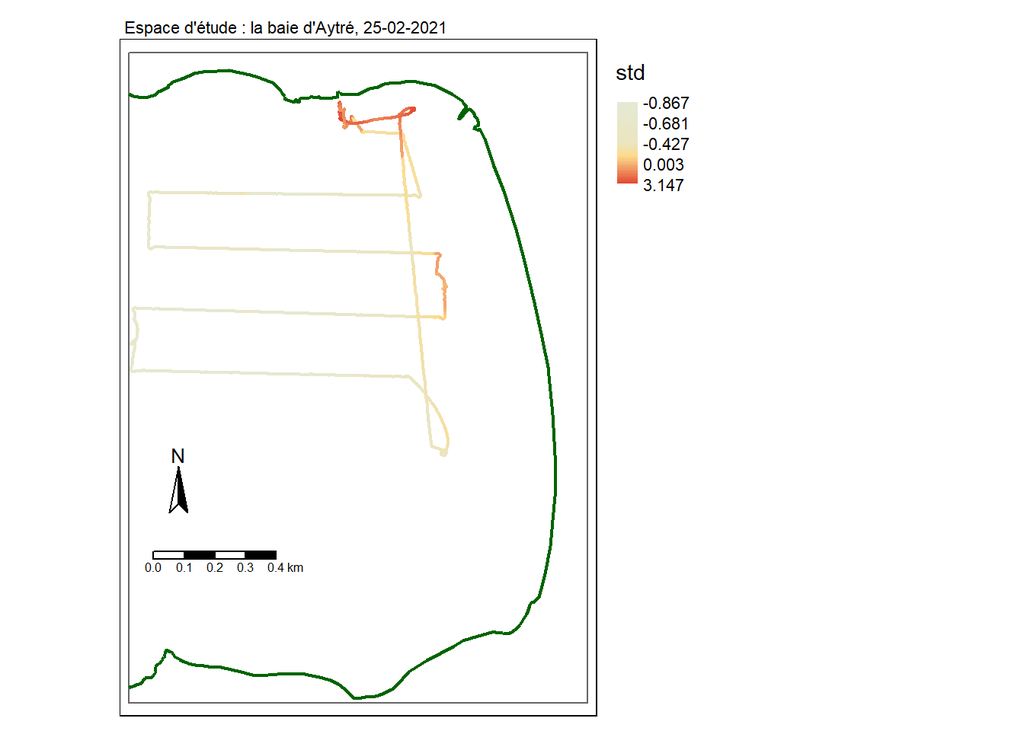

Filtrer le dataset zoomé sur Aytré pour ne traiter que salinité Critère : property_name==‘salinity_ppt’

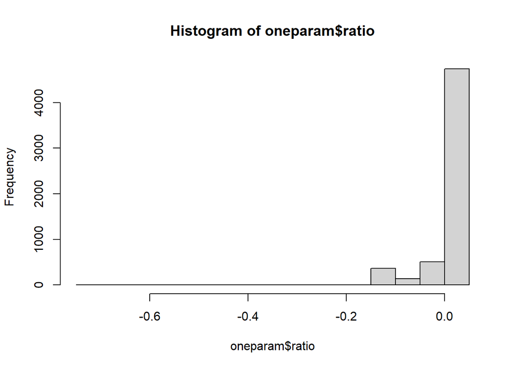

```r
oneparam <- subsetdatasf %>%
  filter(property_name=='salinity_ppt')

hist(oneparam$ratio)
```

```r
median(oneparam$ratio)
```

```
## [1] 0.01217912
```

Carte de salinité

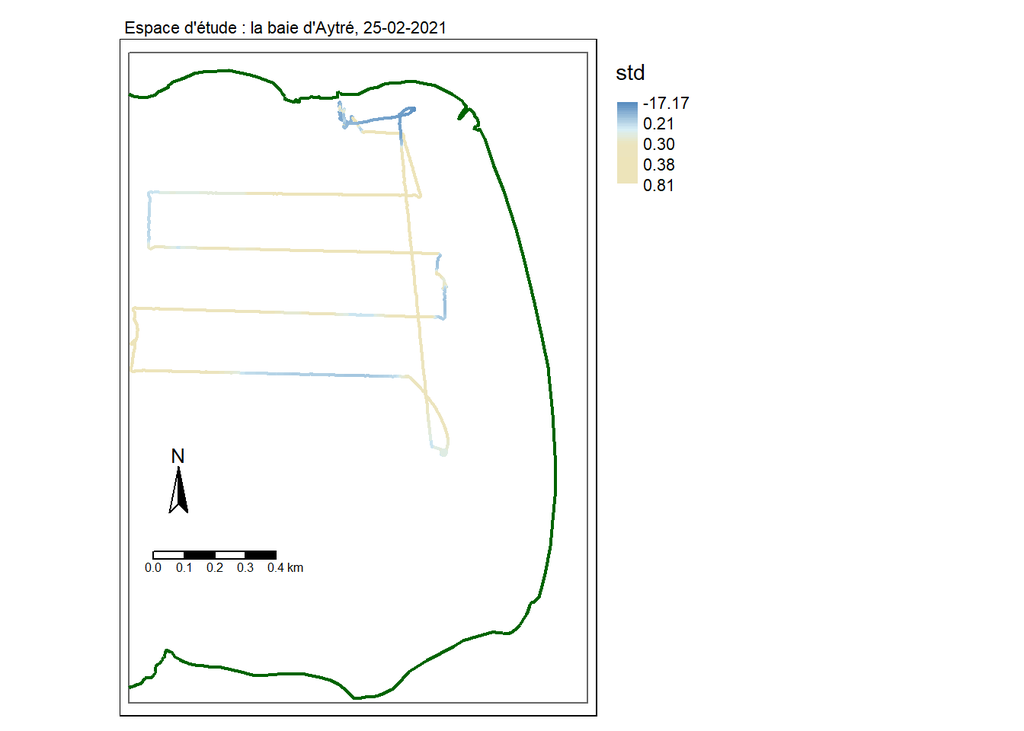

Filtrer le dataset zoomé sur Aytré pour ne traiter que chlorophylle Critère : property_name==‘chlorophyll_RFU’

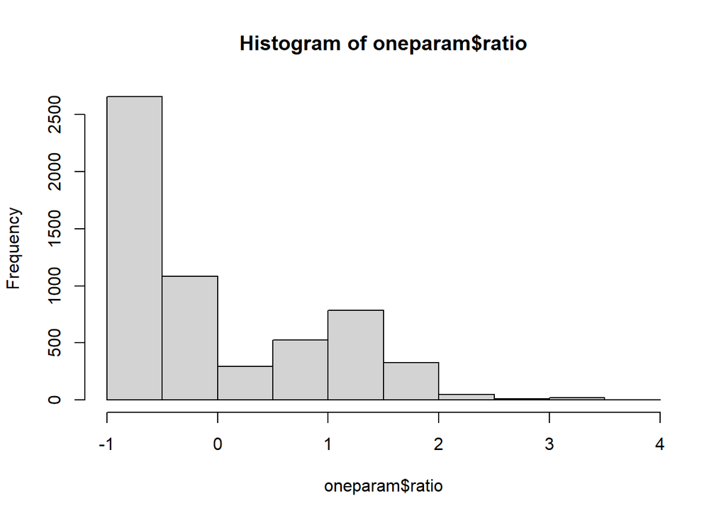

```r
oneparam <- subsetdatasf %>%
  filter(property_name=='chlorophyll_RFU')
hist(oneparam$ratio)
```

```r
median(oneparam$ratio)
```

```
## [1] -0.430864
```

Carte de chlorophylle

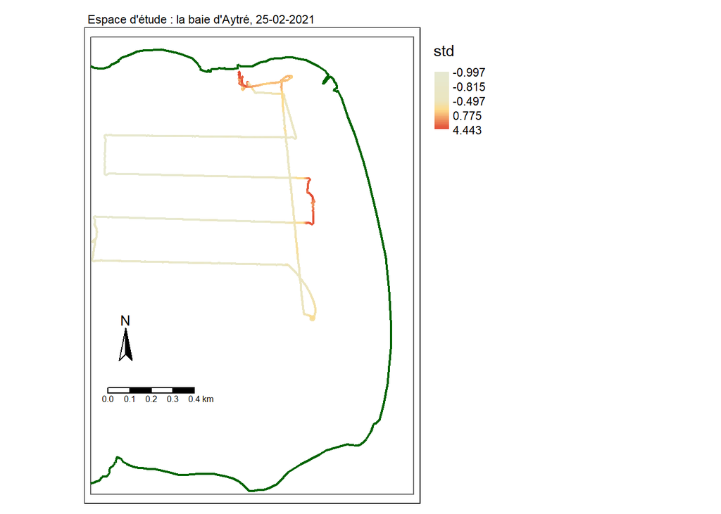

#### 1.3 Superposer les courbes.

Afficher un graphique montrant l’évolution des 4 variables en fonction du temps

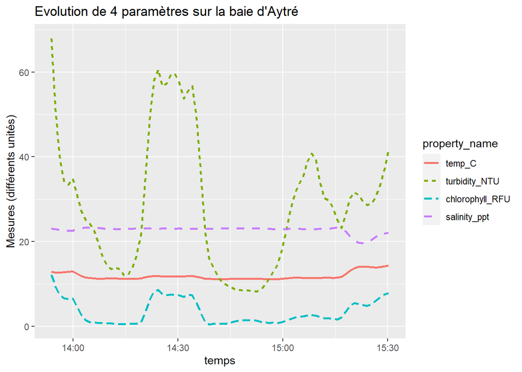

```r
ggplot(data=subsetdatasf, aes(x=local_time, y=property_value, colour=property_name, linetype=property_name)) +
  geom_smooth(method = 'loess', formula = 'y ~ x', span = 0.1, se=FALSE)+
  ggtitle("Evolution de 4 paramètres sur la baie d'Aytré")+ # pour le titre principal
  xlab("temps")+# Légende axe des abscisses
  ylab("Mesures (différents unités)") # pour le titre de l'axe des y
```

```r
#dev.copy(png,'./outputs/raw_4courbes_Aytré.png')
#dev.off()
```

Afficher un graphique montrant l’évolution des 4 variables standardisées en fonction du temps

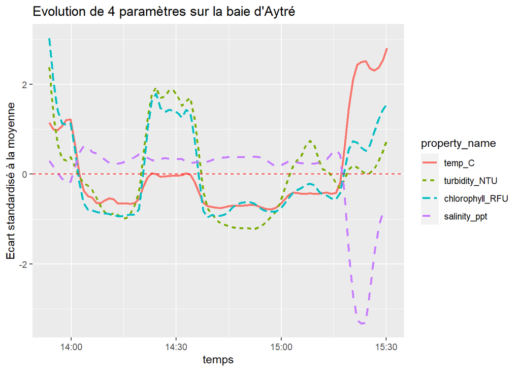

## calculer la distance à la côte

- [aide !](https://gis.stackexchange.com/questions/243994/how-to-calculate-distance-from-point-to-linestring-in-r-using-sf-library-and-g)

```r
colnames(coteprecisez)
```

```
## [1] "NumDep"   "Annee"    "NUM"      "Source"   "COMM"     "Date_PVA" "geometry"
```

```r
colnames(datasfz)
```

```
##  [1] "context_id"     "reason"         "date"           "sensor_name"
##  [5] "property_name"  "property_value" "unit_code"      "unit_name"
##  [9] "point_id"       "pt_longitude"   "pt_latitude"    "local_time"
## [13] "is_reference"   "geom_point"
```

Ne pas exécuter ce chunk de code, mais comprendre :

```r
distances <- st_distance(x = datasfz, y = coteprecisez)
#Pourquoi cette sortie est fausse (expliquez à partir de la lecture de la documentation de st_distance)
rm(distances)
```

Solution

```r
one_singleline <- st_multilinestring(st_geometry(coteprecisez))
one_singleline <- st_sfc(one_singleline)
one_singleline <- st_set_crs(x = one_singleline, value = 4326)

distancesCote <- st_distance(x = subsetdatasf, y = one_singleline)
```

Distribution des distances à la côte calculées

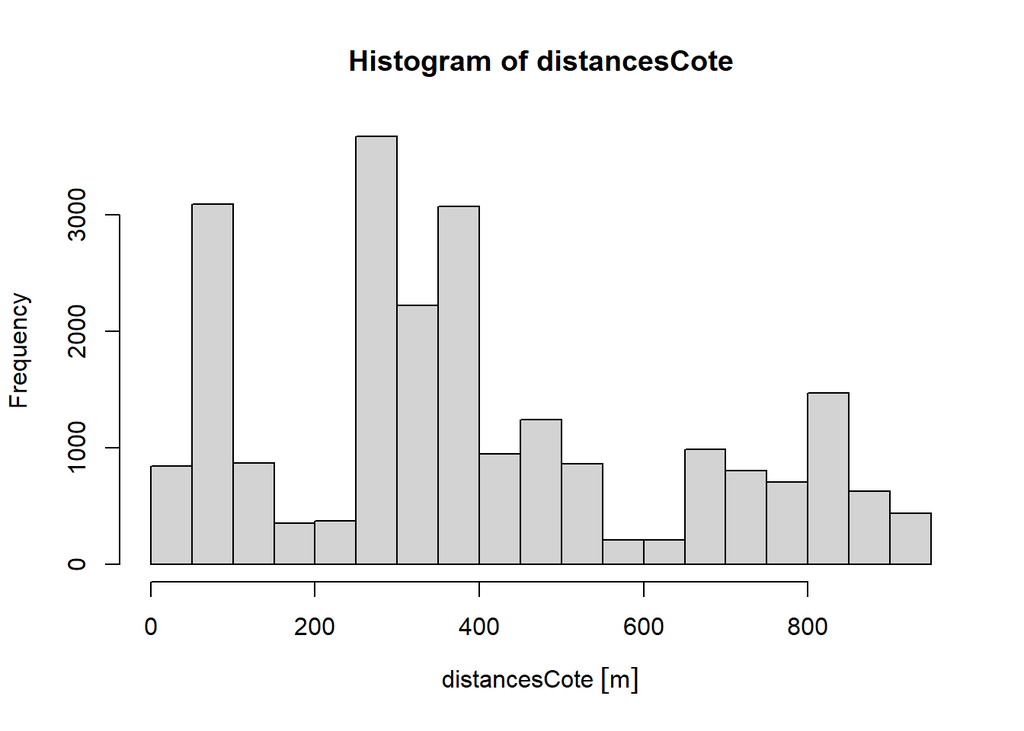

```r
hist(distancesCote)
```

```r
#dev.copy(png,'./outputs/histogramme_distance_cote.png')
#dev.off()
```

Ajouter la distance comme nouvelle variable au jeu de données

```r
subsetdatasf <- cbind(subsetdatasf, distance = as.numeric(distancesCote))
```

Faire une carte de l’évolution de la distance à la cote

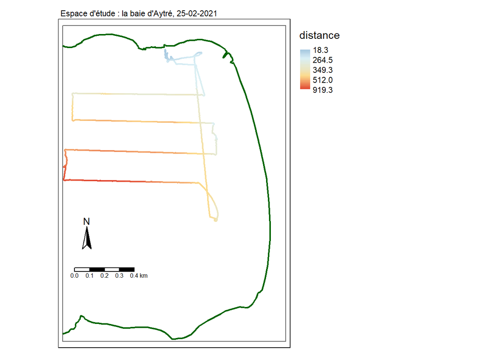

```r
#dev.off()
#png("outputs/distancecote_map_zoom.png", width = sizes_aea[1], height = sizes_aea[2], res = 150)
map_param <- map +
  tm_shape(subsetdatasf) +
  tm_dots(col = "distance", midpoint = median(subsetdatasf$distance), palette=rev(maPalette), style="order")
map_param
```

```r
#dev.off()
```

### calculer la corrélation entre turbidité et distance à la cote

```r
oneparam <- subsetdatasf %>%
  filter(property_name=='turbidity_NTU')
```

Calcul de la corrélation

```r
Mat<-st_drop_geometry(oneparam[,c("property_value", "distance")])
round(cor(Mat), 2)
```

```
##                property_value distance
## property_value           1.00    -0.62
## distance                -0.62     1.00
```

testez aussi avec “ratio”, “std”

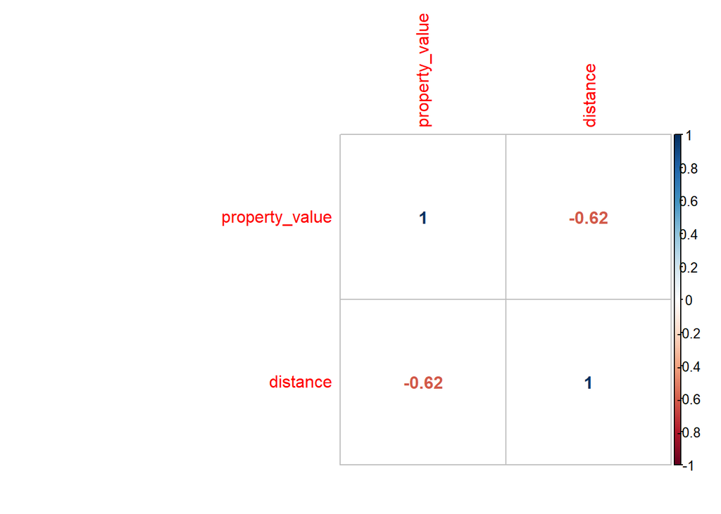

```r
library(corrplot)
corrplot(cor(Mat),method="number")
```

```r
#dev.copy(png,'./outputs/corr_distance_cote_turbidite.png')
#dev.off()

library (Hmisc)
rescorr<-rcorr(as.matrix(Mat))
MatCor<-rescorr$r
MatCor
```

```
##                property_value   distance
## property_value      1.0000000 -0.6191052
## distance           -0.6191052  1.0000000
```

Afficher un graphique montrant l’évolution des 4 variables standardisées avec la distance standardisée à la côte en fonction du temps

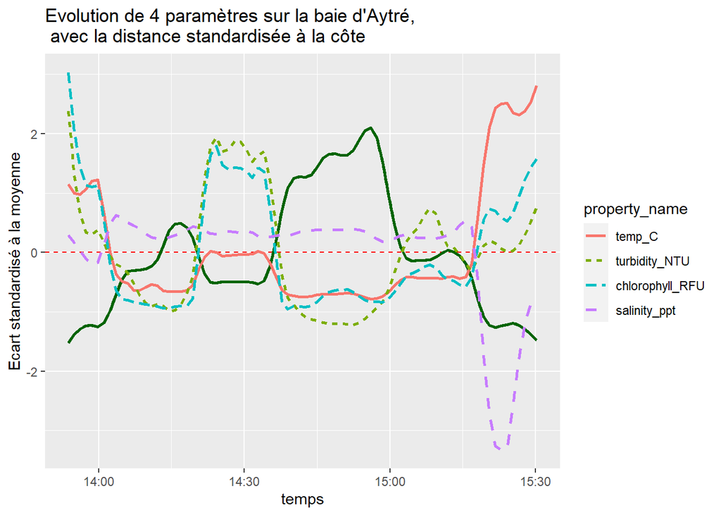

```r
par(mar = c(1,1,1,1), oma = c(1,1,1,1))

ggplot(data=subsetdatasf, aes(x=local_time, y=std, colour=property_name, linetype=property_name)) +
  geom_hline(yintercept=0, linetype="dashed", color = "red")+
  geom_smooth(aes(y=(distance-mean(distance))/sd(distance)), color="#006400", method = 'loess', formula = 'y ~ x', span = 0.1, se=FALSE)+
  geom_smooth(method = 'loess', formula = 'y ~ x', span = 0.1, se=FALSE)+
  ggtitle("Evolution de 4 paramètres sur la baie d'Aytré, \n avec la distance standardisée à la côte")+ # pour le titre principal
  xlab("temps")+# Légende axe des abscisses
  ylab("Ecart standardisé à la moyenne") # pour le titre de l'axe des y
```

```r
#dev.copy(png,'./outputs/5courbes_Aytré_standard.png')
#dev.off()
```